# final project

Xiuyi Qian

10/6/2020

# Introduction

in the current society, with more convenient transportation, there are more connections being built across countries or even across the continents. However, it is a common issue that we all have probably met that we cannot understand the locals when we get to an unfamiliar country.Thus, to improve ourselves and to make our life easier, many universities and high schools have required students to master the second language. And there is a trending that people do get to know more languages than before.

In addition, nowadays, with more travelers around the world, is it equivalent to the point that the more countries people travel to, the more language they get to know. Whether traveling is contingent to the language is one of the topics I am going to analyze.

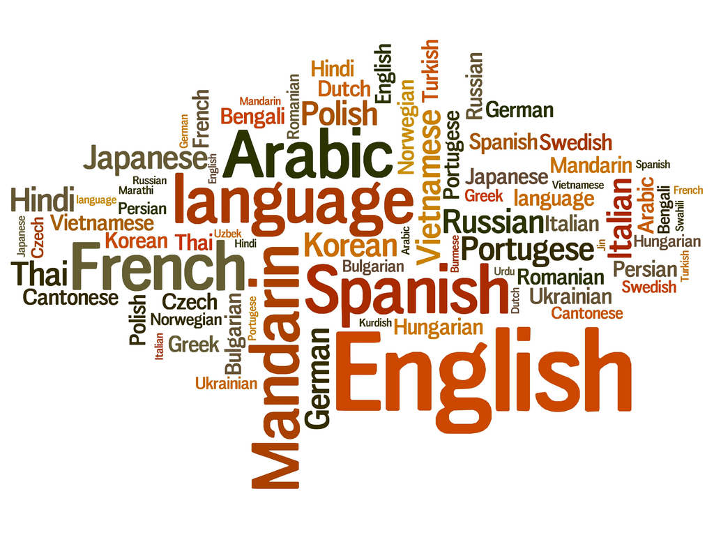

Based on the following studies, I am trying to figure out

1)whether dualcitizen-ship plays key role in the number of languages students speaking

2)whether the number of countries have been to is related to the number of languages speaking

3)whether the international students tend to master more languages

#data set ## The Reference Website and importing data this data set comes from https://www.kaggle.com/. Kaggle is a data collecting website using over 50,00 public data sets and over 400,00 public notebooks.

```r
cac <- read.csv("D:/Emory/Econ220lab/final/countries and continents.csv", header=FALSE)
TravelStudy <- read.csv("D:/Emory/Econ220lab/final/TravelStudy.csv")
```

## External Sources and Data

Travel Study This data was collected as part of a travel study conducted by my Advanced Statistics students.

The variables are described below, DomInt: “Are you an international or domestic student?” DayBoarding: “Are you a day or boarding student?” Countries: “How many countries have you been to?” Languages: “How many languages do you speak?” DualCitizenship: “Do you have dual citizenship?”

The reason I choose this data is due to that I can build the association between countries students have been to with the languages they can speak. As I have mentioned in the introduction that the hobby of traveling around the world may be a key factor associating with the number of languages students know

```r
ts <- TravelStudy %>% select(DomInt, Countries, Languages, DualCitizenship)
str(ts)
```

```
## 'data.frame':    95 obs. of  4 variables:
##  $ DomInt         : chr  "Domestic" "International" "Domestic" "International" ...
##  $ Countries      : int  1 2 1 5 1 3 0 9 11 3 ...
##  $ Languages      : int  1 3 1 3 1 1 2 2 4 2 ...
##  $ DualCitizenship: chr  "No" "No" "Yes" "No" ...
```

```r
head(ts,6)
```

```
##          DomInt Countries Languages DualCitizenship
## 1      Domestic         1         1              No
## 2 International         2         3              No
## 3      Domestic         1         1             Yes
## 4 International         5         3              No
## 5      Domestic         1         1              No
## 6      Domestic         3         1              No
```

```r
summary(ts)
```

```
##     DomInt            Countries        Languages     DualCitizenship
##  Length:95          Min.   : 0.000   Min.   :1.000   Length:95
##  Class :character   1st Qu.: 2.000   1st Qu.:1.000   Class :character
##  Mode  :character   Median : 5.000   Median :1.000   Mode  :character
##                     Mean   : 7.053   Mean   :1.768
##                     3rd Qu.:10.000   3rd Qu.:2.000
##                     Max.   :50.000   Max.   :5.000
```

top six samples of the data

## Analysis or summary of data

```r
ts%>%select(Countries,Languages)%>%summarise(mean_country = mean(ts$Countries,na.rm = TRUE),mean_languages = mean(ts$Languages,na.rm=TRUE), sd_country = sd(ts$Countries,na.rm = TRUE), sd_language=sd(ts$Languages,na.rm = TRUE),
median_countries = median(ts$Countries,na.rm = TRUE),
median_languages = median(ts$Languages,na.rm = TRUE)
)
```

```
##   mean_country mean_languages sd_country sd_language median_countries
## 1     7.052632       1.768421   7.186525   0.9941599                5
##   median_languages
## 1                1
```

```r
(c <- table(ts$DomInt,ts$DualCitizenship))
```

```
##
##                 No Yes
##   Domestic      46   6
##   International 37   6
```

```r
kable(prop.table(c), digits=3,  caption = "DomInt by Dual-Cit") %>% kable_styling(bootstrap_options = c("striped", "hover"),full_width = F) %>%  add_header_above(c("Student-Type"=1,"Dual-Citizen"=2))
```

DomInt by Dual-Cit

| Student-Type | Dual-Citizen No | Dual-Citizen Yes |
| --- | --- | --- |
| Domestic | 0.484 | 0.063 |
| International | 0.389 | 0.063 |

# Data cleaning

create a new column called NT(number of countries had gone to)

```r
ts$NT<-factor(ts$Countries,levels = c("zero","one","between 2 and 4", "between 5 and 9","more than 10"),ordered = TRUE )
ts$NT[ts$Countries==0] <- "zero"
ts$NT[ts$Countries==1] <- "one"
ts$NT[ts$Countries>1  & ts$Countries<5] <- "between 2 and 4"
ts$NT[ts$Countries>=5 & ts$Countries<10] <- "between 5 and 9"
ts$NT[ts$Countries>=10] <- "more than 10"
summary(ts$NT)
```

```
##            zero             one between 2 and 4 between 5 and 9    more than 10
##               2              17              22              29              25
```

sepearing the international student and domestic

```r
inter<- ts %>% filter(DomInt=="Domestic")
dom <- ts %>%filter(DomInt=="International")

nrow_inter <-nrow(inter)
nrow_dom <-nrow(dom)

head(inter,5)
```

```
##     DomInt Countries Languages DualCitizenship              NT
## 1 Domestic         1         1              No             one
## 2 Domestic         1         1             Yes             one
## 3 Domestic         1         1              No             one
## 4 Domestic         3         1              No between 2 and 4
## 5 Domestic         0         2              No            zero
```

```r
head(dom,5)
```

```
##          DomInt Countries Languages DualCitizenship              NT
## 1 International         2         3              No between 2 and 4
## 2 International         5         3              No between 5 and 9
## 3 International         9         2              No between 5 and 9
## 4 International        11         4              No    more than 10
## 5 International         3         2              No between 2 and 4
```

52 domestic students and 43 international students

#data analysis ## max number intern and dom students have been to

```r
inter_c <- inter%>%arrange(desc(Countries))
dom_c <- dom%>%arrange(desc(Countries))
inter_c$Countries[1]
```

```
## [1] 22
```

```r
dom_c$Countries[1]
```

```
## [1] 50
```

## comparison of domestic and international ones

```r
mean(ts[ts$DomInt=="Domestic",]$Countries,na.rm = TRUE)
```

```
## [1] 4.269231
```

```r
mean(ts[ts$DomInt=="International",]$Countries,na.rm = TRUE)
```

```
## [1] 10.4186
```

```r
mean(ts$Countries,na.rm = TRUE)
```

```
## [1] 7.052632
```

mean of countries domestic students going is around 4 (4.27) mean of countries international students going is around 10 (10.42)

which indicates international studens go far more countries than domestic ones do * overall, the mean number of countries students go is 7

# Confidence intervals and Two sample t test

## number of countries domestic and international students have travelled to

1. null hypothesis: the difference between number of countries domestic and international students have traveled to is zero

alternative hypothesis: the difference number of countries domestic and international students have traveled to is zero is not zero

```r
t.test(Countries ~ DomInt, data = ts)
```

```
##
##  Welch Two Sample t-test
##
## data:  Countries by DomInt
## t = -4.3346, df = 61.68, p-value = 5.487e-05
## alternative hypothesis: true difference in means is not equal to 0
## 95 percent confidence interval:
##  -8.985536 -3.313212
## sample estimates:
##      mean in group Domestic mean in group International
##                    4.269231                   10.418605
```

## number of languages domestic and international students have mastered

2. null hypothesis: the difference between number of languages domestic and international students have learned is zero

alternative hypothesis: the difference number of language domestic and international students have learned is not zero

```r
t.test(Languages ~ DomInt, data = ts)
```

```
##
##  Welch Two Sample t-test
##
## data:  Languages by DomInt
## t = -6.7774, df = 58.07, p-value = 6.889e-09
## alternative hypothesis: true difference in means is not equal to 0
## 95 percent confidence interval:
##  -1.5386538 -0.8370171
## sample estimates:
##      mean in group Domestic mean in group International
##                    1.230769                    2.418605
```

# Graphs

## comparison of population of dual-citizen and non-dual citizen

[figure not shown]

```r
ggplot(ts, mapping=aes(x=DualCitizenship)) +
  geom_bar(fill="lightgreen") +
  ylab("Countries had been to") + xlab("DualCitizenship") +
  ggtitle("Figure 1:Dual-citizen and non-Dual-citizen population") +
  theme(plot.title = element_text(hjust = 0.5))
```

Non-Dual citizenship occupies a bigger proportion of the sample.

## distribution of countries

```r
quantile(ts$Countries)
```

```
##   0%  25%  50%  75% 100%
##    0    2    5   10   50
```

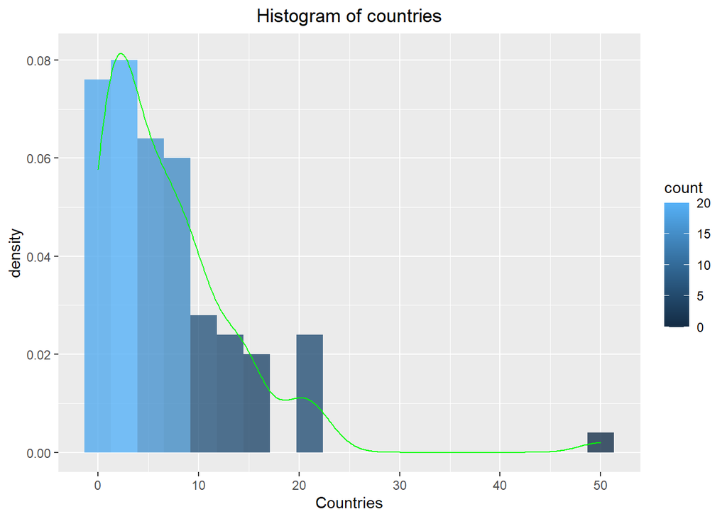

```r
ggplot(ts, aes(x=Countries)) +
geom_histogram(aes(y =..density.., fill=..count..), bins=20, alpha = .8)+ #
   geom_density(col="green") +
labs(title="Histogram of countries")+
   theme(plot.title = element_text(hjust = 0.5))
```

## quantile of dual-citizen group and non-dual-citizen’s

From the density histogram graph, we can see the range of countries students have been traveling to still concentrates on the rage from 0 to 15.Thus, for the following graph, I’d like to to concentrate my analysis without outliers.

```r
quantile(ts[ts$DualCitizenship=="Yes",]$Countries)
```

```
##    0%   25%   50%   75%  100%
##  1.00  6.50  9.50 12.75 20.00
```

```r
quantile(ts[ts$DualCitizenship=="No",]$Countries)
```

```
##   0%  25%  50%  75% 100%
##    0    2    5    9   50
```

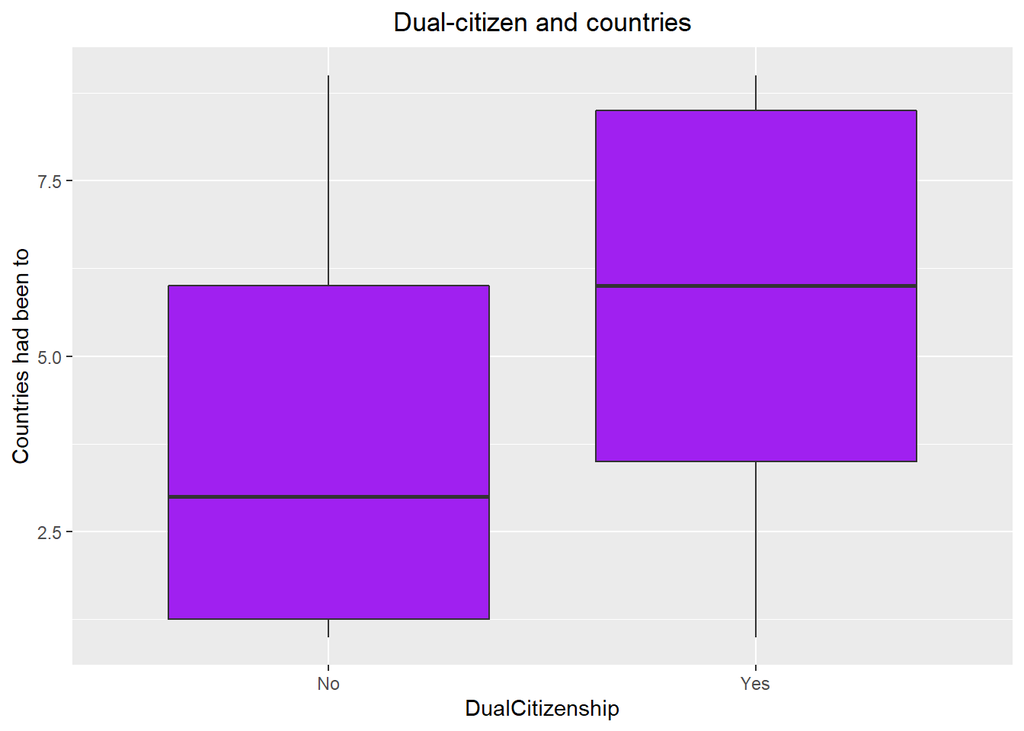

```r
ts_over_5 <- subset(ts, ts$NT=="between 5 and 9"|ts$NT=="between 2 and 4"| ts$NT=="one")
ggplot(ts_over_5, mapping=aes(x=DualCitizenship, y=Countries)) +
  geom_boxplot(fill="purple") +
  ylab("Countries had been to") + xlab("DualCitizenship") +
  ggtitle("Dual-citizen and countries") +
  theme(plot.title = element_text(hjust = 0.5))
```

Average number of countries Students with DualCitizenShip have been to is more than the non-dual-citizens do. And from the quantiled data we can see the 25th to 75th population of Dual citizenship is from 6.5 to 12.75 while non-dual citizen ship is from 2 to 9.

## correlation between countries and languages based on the group of students type (dom and Int)

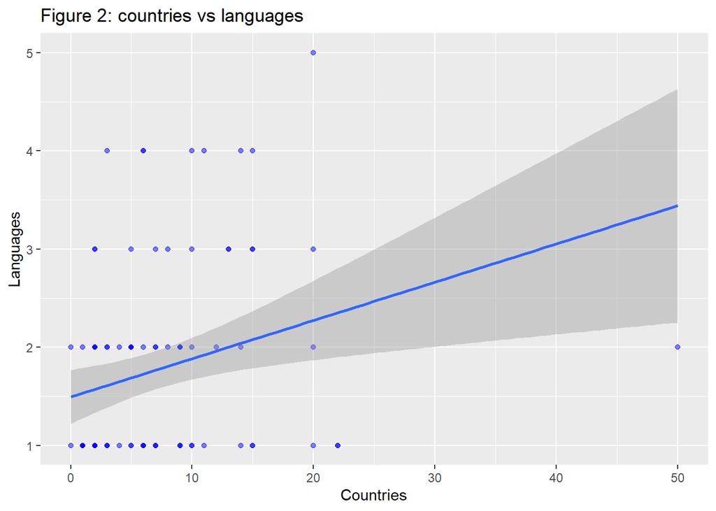

```r
ggplot(ts, aes(Countries, Languages)) + geom_point(color = "blue", alpha = 0.5) +
    geom_smooth(method = "lm") + ggtitle("Figure 2: countries vs languages")
```

[figure not shown]

```r
ggplot(inter_c,aes(x=Countries, y= Languages))+
   geom_smooth(method = "lm")+
  geom_point( alpha = 0.2, size=3, shape=6, color= "brown")+
  labs(x="countries",y="languages",title="Figure 3:countries vs    languages for international")+
  theme_minimal()
```

[figure not shown]

```r
ggplot(dom_c,aes(x=Countries, y= Languages))+
   geom_smooth(method = "lm")+
  geom_point( alpha = 0.2, size=3, shape=6, color= "red")+
  labs(x="countries",y="languages",title="Figure 4 :countries vs languages for domestic")+
  theme_minimal()
```

```r
cor(ts$Countries,ts$Languages)
```

```
## [1] 0.2816576
```

```r
cor(inter_c$Countries,inter_c$Languages)
```

```
## [1] -0.01907012
```

```r
cor(dom_c$Countries,dom_c$Languages)
```

```
## [1] 0.05275033
```

# Conclusion

It is easy for people to think in the way that learning a new language when traveling is the best way.It makes getting around easier; whether it’s for reading signs or asking directions – it saves you from the likelihood of getting lost in a foreign country. Traveling introduces a lot of diversity as well.Getting to know the native people that you might never again come across holds an excitement that just can’t be missed. However, at least to students, from the data we can see it is probably not the case.

To conclude and summarize the findings of the statistics:

1. Firstly, there is difference between number of language domestic and international students have learned from the t statistics.

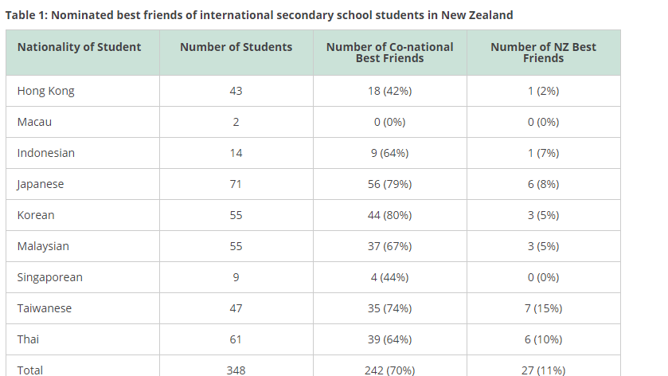

# Reference

https://www.educationcounts.govt.nz/publications/international/the_impact_of_international_students_on_domestic_students_and_host_institutions

https://etoninstitute.com/blog/5-benefits-of-learning-new-language-when-travelling